# Assignment V: GitHub and the ticketmaster.com API

Data Science Project Management | Winter Term 2020/21

Submitted by Franziska Müller (Student ID: 5401673)

February, 15, 2021

I hereby assure that my submission is in line with the *Code of Conduct* outlined on the lecture slides. I worked on my own.

## General setup

Before I start the project, I clear my workspace. Please source your individual key and set your individual working directory.

```r
# Clear workspace
rm(list = ls())

# Source private key - insert your indicidual path to the key
source("C:/Users/Francesca/Desktop/MA_WiSe 202021/Data Science Project Management/Assignments/key_ticketmaster.R")

# Modify individual working directory
# Replace working directory by your individual wd here
BasicFilePath <- file.path("C:/Users/Francesca/Documents/GitHub/DSPM_AssignmentV")
setwd(BasicFilePath)
```

## Exercise 1: Setting up a GitHub repository

Please find my repository via: https://github.com/FrancescaMueller/DSPM_AssignmentV.git

## Exercise 2: Getting to know the API

Rate limit is given by 5 requests per second and max. 5,000 requests per day.

## Exercise 3: Interacting with the API - the basics

*Load the packages needed to interact with APIs using R.*

```r
# Check if packages have been installed before; if not, install them
if (!require("jsonlite")) install.packages("jsonlite")
if (!require("httr")) install.packages("httr")
if (!require("rlist")) install.packages("rlist")
if (!require("tidyverse")) install.packages("tidyverse")
if (!require("tidyr")) install.packages("tidyr")
if (!require("dplyr")) install.packages("dplyr")

# Load packages
library(jsonlite)
library(dplyr)
library(httr)
library(rlist)
library(tidyverse)
library(tidyr)
```

*Perform a first GET request, that searches for event venues in Germany (countryCode = “DE”). Extract the content from the response object and inspect the resulting list. Describe what you can see.*

```r
my_url <- paste0("https://app.ticketmaster.com/discovery/v2/venues?apikey=", key)

first_glimpse <- function(country, page) {
  resp_obj <- GET(url = paste0(my_url,
                               "&locale=*&page=",
                               page,
                               "&countryCode=",
                               country))
  cont_obj <- resp_obj %>% content()
  return(cont_obj)
}

country <- 'DE'
Ex3_first_glimpse <- first_glimpse(country, 0)
# Use page = 0 in order to get the first 20 results
```

*Extract ‘name’, ‘city’, ‘postalCode’, ‘adress’, ‘url’, longitude’, ‘latitude’.*

```r
# Function GET CONTENT
get_content <- function(country, page) {
  resp_obj <- GET(url = paste0(my_url,
                               "&locale=*&page=",
                               page,
                               "&countryCode=",
                               country))
  cont_obj <- fromJSON(content(x = resp_obj,
                               as = 'text'))

  # Keep just relevant information about venues in general
  placeholder <- as.data.frame(cont_obj$`_embedded`$venues)

  # Just keep relevant information asked by the assignment
  df <- data.frame(placeholder$name, placeholder$city[1],
                   placeholder$postalCode, placeholder$address, placeholder$url
                   )

  # Adjust for location
  if (is.null(placeholder$location) == TRUE) {
    df['longitude'] <- NA
    df['latitude'] <- NA
  } else{
    df <- df %>% cbind(placeholder$location[1], placeholder$location[2])
  }

  # Rename columns
  names(df) <- c("name", "city", "postalCode", "address", "url", "longitude", "latitude")

  # Change longitude and latitude to type double
  df$longitude <- df$longitude %>% as.double()
  df$latitude <- df$latitude %>% as.double()

  return(df)
}

Ex3 <- get_content(country, 0)

glimpse(Ex3)
```

```
## Rows: 20
## Columns: 7
## $ name       <chr> "Gruenspan", "Philharmonie (Großer Saal)", "Beatpol", "M...
## $ city       <chr> "Hamburg", "Berlin", "Dresden", "Ludwigsburg", "Berlin",...
## $ postalCode <chr> "22767", "10785", "01157", "71638", "12435", "79108", "7...
## $ address    <chr> "Grosse Freiheit 58", "Herbert-von-Karajan-Straße 1", "A...
## $ url        <chr> "http://www.ticketmaster.de/venue/287155", "https://www....
## $ longitude  <dbl> 9.958075, 13.368960, 13.674710, 9.182400, 13.420540, 7.8...
## $ latitude   <dbl> 53.55188, 52.51007, 51.06498, 48.89121, 52.49945, 48.015...
```

## Exercise 4: Interacting with the API - advanced

*Have a closer look at the element list named `page`.* There are `612` pages with `12238` elements in total. With the parameter `page` different pages can be accessed.

```r
pages <- as.numeric(Ex3_first_glimpse[["page"]][["totalPages"]])  # Number of total pages
pages_loop <- pages - 1 # Counting from 0 to 611, in total 612 pages
n <- as.numeric(nrow(Ex3))  # Number of elements per page
m <- as.numeric(Ex3_first_glimpse[["page"]][["totalElements"]])  # Number total elements

# Controlling for remainder
# pages == floor(m/n)  # False
# Note: need to consider last page as special case since the function all_pages cannot handle df with less than n = 20 rows

# Create empty data frame
df_Ex4 <- tibble(name = character(m),
                 city = character(m),
                 postalCode = character(m),
                 adress = character(m),
                 url = character(m),
                 longitude = double(m),
                 latitude = double(m))

# Loop
all_pages <- function(country, number_pages, df_all_pages) {
  for (j in 0:number_pages) {
    tryCatch({
      cont_obj <- get_content(country, j)
      df_all_pages[(20 + 20 * j - 19):(20 + 20 * j),] <- cont_obj
      Sys.sleep(time = 0.3)
      # 5 requests per second allowed, but adjusted since error prone
    },
    error = function(e){})
  }
  return(df_all_pages)
  }

# Get info all pages
Ex4_all <- all_pages(country, pages_loop, df_Ex4)
# Add information for last page
Ex4_all[12221:m,] <- get_content(country, pages_loop)

# Save created data frame
saveRDS(Ex4_all, file = "./data/data_DE.rds")

glimpse(Ex4_all)
```

```
## Rows: 12,238
## Columns: 7
## $ name       <chr> "Gruenspan", "Philharmonie (Großer Saal)", "Beatpol", "M...
## $ city       <chr> "Hamburg", "Berlin", "Dresden", "Ludwigsburg", "Berlin",...
## $ postalCode <chr> "22767", "10785", "01157", "71638", "12435", "79108", "7...
## $ adress     <chr> "Grosse Freiheit 58", "Herbert-von-Karajan-Straße 1", "A...
## $ url        <chr> "http://www.ticketmaster.de/venue/287155", "https://www....
## $ longitude  <dbl> 9.958075, 13.368960, 13.674710, 9.182400, 13.420540, 7.8...
## $ latitude   <dbl> 53.55188, 52.51007, 51.06498, 48.89121, 52.49945, 48.015...
```

## Exercise 5: Visualizing the extended data

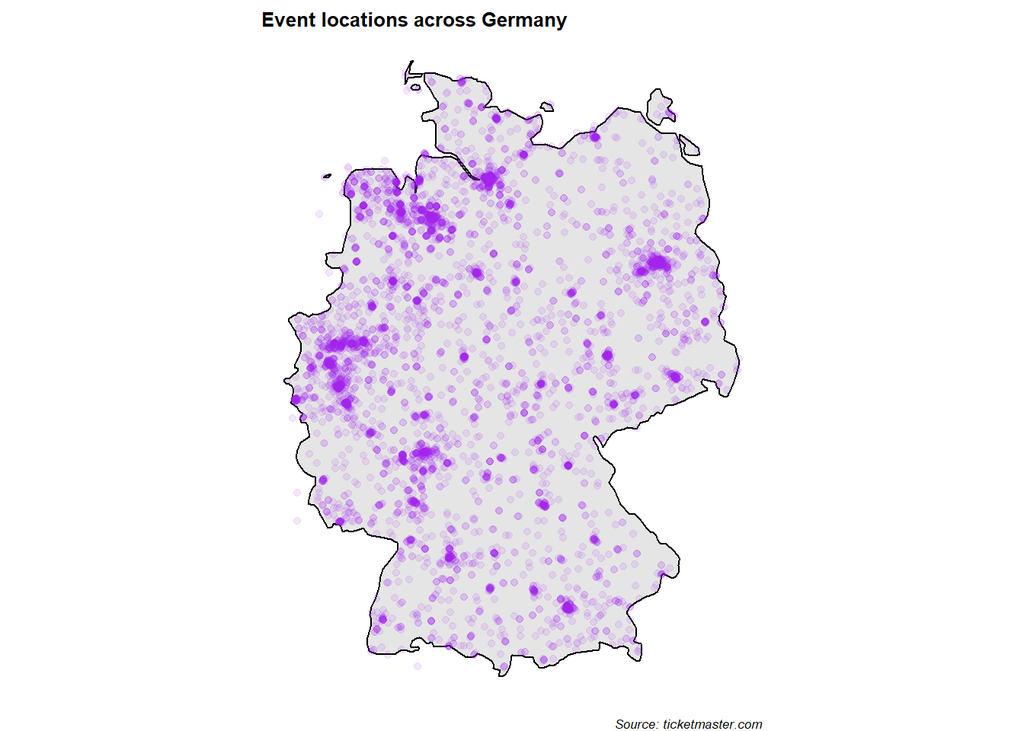

```r
# Prepare data frame
# Note: filter() would be more effective but the assigment asks to assign NA to unwanted data - so first, NAs will be introduced, second, df will adapted to purpose (remove rows containing NAs in longitude/latitude column etc.).

Ex5 <- Ex4_all %>% mutate(longitude = replace(
  x = longitude,
  list = longitude < 5.86694,
  values = NA
))
Ex5 <- Ex5 %>% mutate(longitude = replace(
  x = longitude,
  list = longitude > 15.043611,
  values = NA
))

Ex5 <- Ex5 %>% mutate(latitude = replace(
  x = latitude,
  list = latitude < 47.271679,
  values = NA
))

Ex5 <- Ex5 %>% mutate(latitude = replace(
  x = latitude,
  list = latitude > 55.0846,
  values = NA
))

# Remove unneded rows for the plot
Ex5_plot <- Ex5[complete.cases(Ex5[ , 6:7]), ]

# Plot
plot_DE <- ggplot() +
  geom_polygon(
    aes(x = long, y = lat, group = group),
    data = map_data("world", region = "Germany"),
    fill = "grey90",
    color = "black"
  ) +
  geom_point(
    mapping = aes(x = longitude,
                  y = latitude),
    data = Ex5_plot,
    color = "purple",
    alpha = 0.1
  ) +
  theme_void() + coord_quickmap() +
  labs(title = "Event locations across Germany", caption = "Source: ticketmaster.com") +
  theme(title = element_text(size = 8, face = 'bold'),
        plot.caption = element_text(face = "italic"))

plot_DE
```